# si544-day11-inference-for-regression

Drew Pappas

11/15/2019

```r
library(tidyverse)
```

```r
library(infer)
library(moderndive)
library(dplyr)
library(ggplot2)
library(knitr)
```

```r
glimpse(house_prices)
```

```
## Observations: 21,613
## Variables: 21
## $ id            <chr> "7129300520", "6414100192", "5631500400", "24872...
## $ date          <date> 2014-10-13, 2014-12-09, 2015-02-25, 2014-12-09,...
## $ price         <dbl> 221900, 538000, 180000, 604000, 510000, 1225000,...
## $ bedrooms      <int> 3, 3, 2, 4, 3, 4, 3, 3, 3, 3, 3, 2, 3, 3, 5, 4, ...
## $ bathrooms     <dbl> 1.00, 2.25, 1.00, 3.00, 2.00, 4.50, 2.25, 1.50, ...
## $ sqft_living   <int> 1180, 2570, 770, 1960, 1680, 5420, 1715, 1060, 1...
## $ sqft_lot      <int> 5650, 7242, 10000, 5000, 8080, 101930, 6819, 971...
## $ floors        <dbl> 1.0, 2.0, 1.0, 1.0, 1.0, 1.0, 2.0, 1.0, 1.0, 2.0...
## $ waterfront    <lgl> FALSE, FALSE, FALSE, FALSE, FALSE, FALSE, FALSE,...
## $ view          <int> 0, 0, 0, 0, 0, 0, 0, 0, 0, 0, 0, 0, 0, 0, 0, 3, ...
## $ condition     <fct> 3, 3, 3, 5, 3, 3, 3, 3, 3, 3, 3, 4, 4, 4, 3, 3, ...
## $ grade         <fct> 7, 7, 6, 7, 8, 11, 7, 7, 7, 7, 8, 7, 7, 7, 7, 9,...
## $ sqft_above    <int> 1180, 2170, 770, 1050, 1680, 3890, 1715, 1060, 1...
## $ sqft_basement <int> 0, 400, 0, 910, 0, 1530, 0, 0, 730, 0, 1700, 300...
## $ yr_built      <int> 1955, 1951, 1933, 1965, 1987, 2001, 1995, 1963, ...
## $ yr_renovated  <int> 0, 1991, 0, 0, 0, 0, 0, 0, 0, 0, 0, 0, 0, 0, 0, ...
## $ zipcode       <fct> 98178, 98125, 98028, 98136, 98074, 98053, 98003,...
## $ lat           <dbl> 47.5112, 47.7210, 47.7379, 47.5208, 47.6168, 47....
## $ long          <dbl> -122.257, -122.319, -122.233, -122.393, -122.045...
## $ sqft_living15 <int> 1340, 1690, 2720, 1360, 1800, 4760, 2238, 1650, ...
## $ sqft_lot15    <int> 5650, 7639, 8062, 5000, 7503, 101930, 6819, 9711...
```

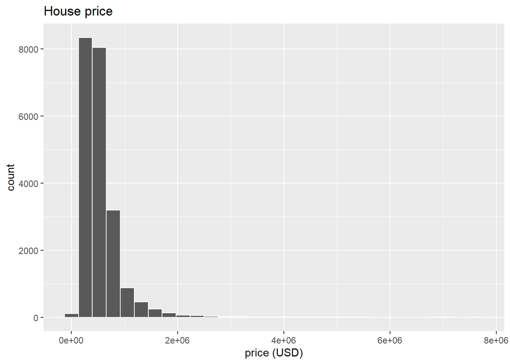

```r
ggplot(house_prices, aes(x = price)) +
  geom_histogram(color = "white") +
  labs(x = "price (USD)", title = "House price")
```

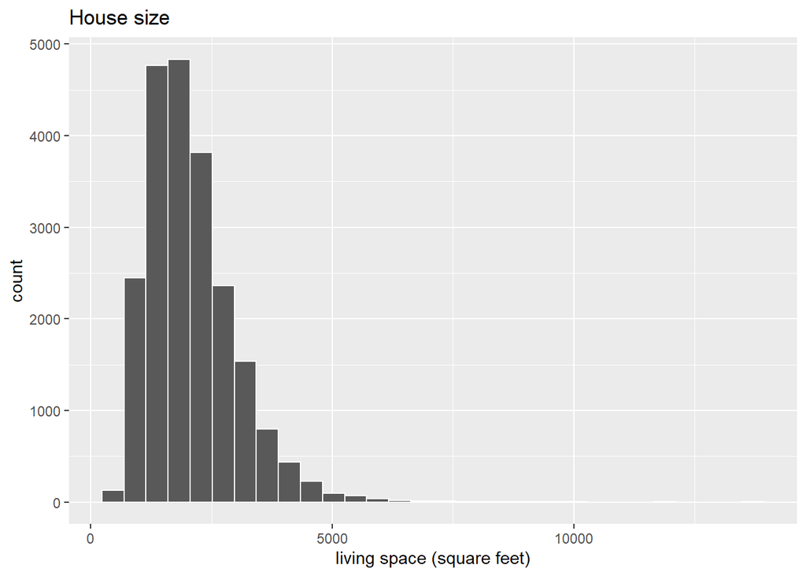

```r
ggplot(house_prices, aes(x = sqft_living)) +
  geom_histogram(color = "white") +
  labs(x = "living space (square feet)", title = "House size")
```

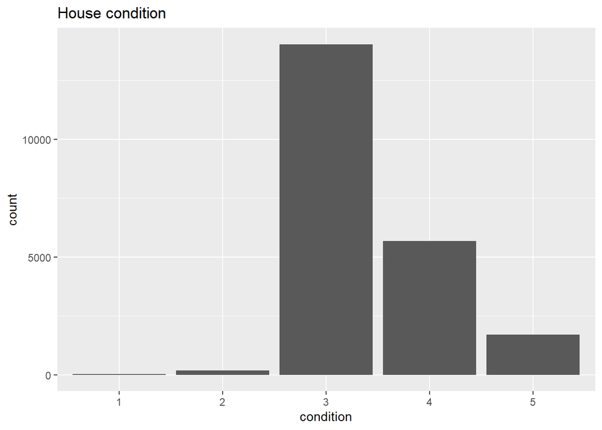

```r
# Barplot of condition:
ggplot(house_prices, aes(x = condition)) +
  geom_bar() +
  labs(x = "condition", title = "House condition")
```

```r
house_prices %>%
  summarize(
    mean_price = mean(price),
    median_price = median(price),
    sd_price = sd(price),
    IQR_price = IQR(price)
  )
```

```
## # A tibble: 1 x 4
##   mean_price median_price sd_price IQR_price
##        <dbl>        <dbl>    <dbl>     <dbl>
## 1    540088.       450000  367127.    323050
```

```r
house_prices <- house_prices %>%
  mutate(
    log10_price = log10(price),
    log10_size = log10(sqft_living)
    )
```

```r
house_prices %>%
  select(price, log10_price, sqft_living, log10_size)
```

```
## # A tibble: 21,613 x 4
##      price log10_price sqft_living log10_size
##      <dbl>       <dbl>       <int>      <dbl>
##  1  221900        5.35        1180       3.07
##  2  538000        5.73        2570       3.41
##  3  180000        5.26         770       2.89
##  4  604000        5.78        1960       3.29
##  5  510000        5.71        1680       3.23
##  6 1225000        6.09        5420       3.73
##  7  257500        5.41        1715       3.23
##  8  291850        5.47        1060       3.03
##  9  229500        5.36        1780       3.25
## 10  323000        5.51        1890       3.28
## # ... with 21,603 more rows
```

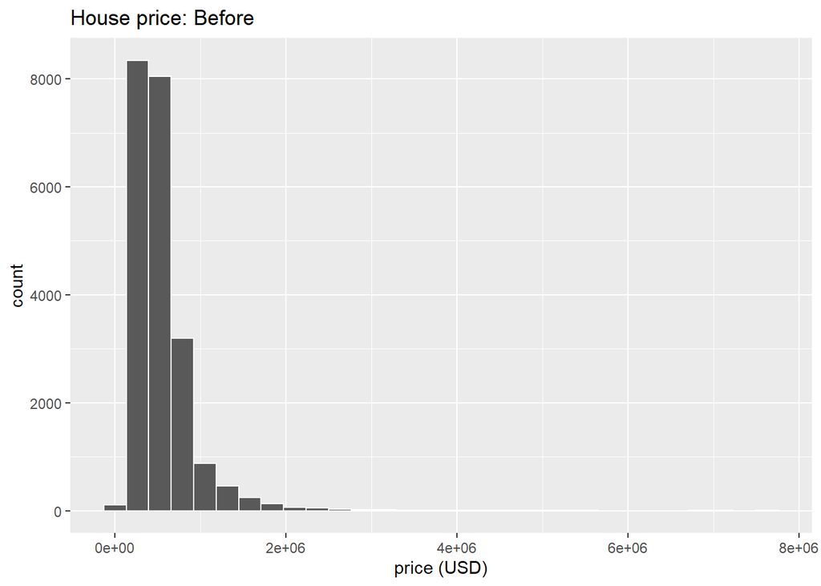

```r
# Before:
ggplot(house_prices, aes(x = price)) +
  geom_histogram(color = "white") +
  labs(x = "price (USD)", title = "House price: Before")
```

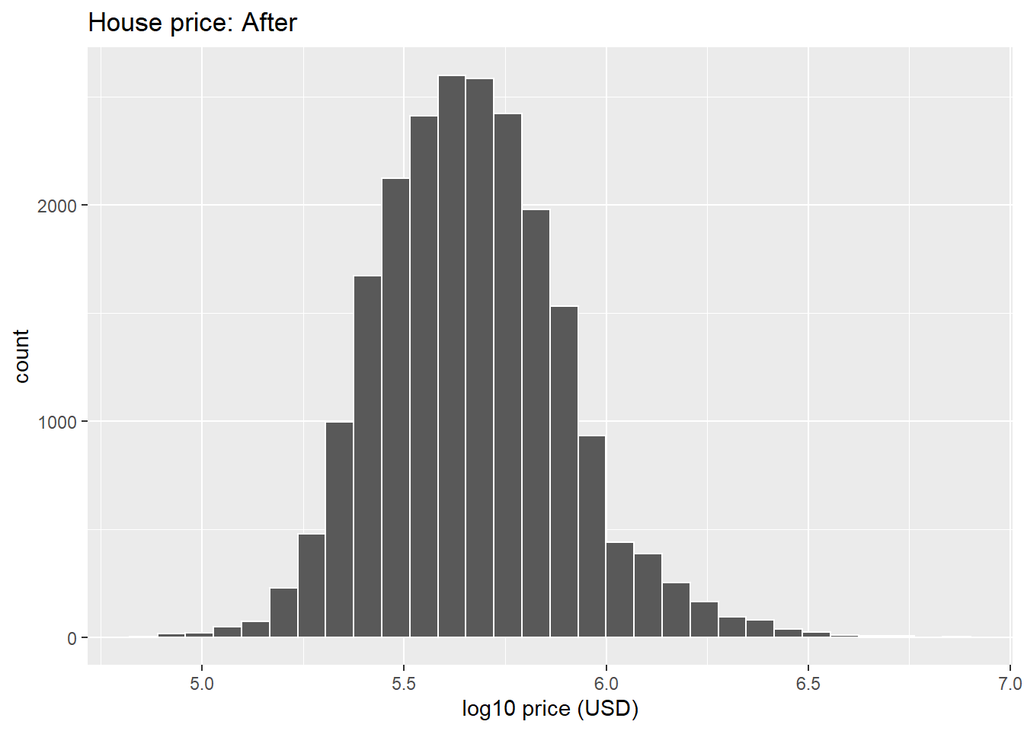

```r
# After:
ggplot(house_prices, aes(x = log10_price)) +
  geom_histogram(color = "white") +
  labs(x = "log10 price (USD)", title = "House price: After")
```

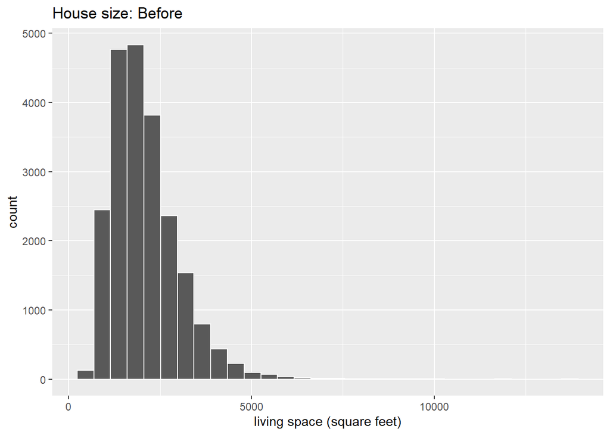

```r
# Before:
ggplot(house_prices, aes(x = sqft_living)) +
  geom_histogram(color = "white") +
  labs(x = "living space (square feet)", title = "House size: Before")
```

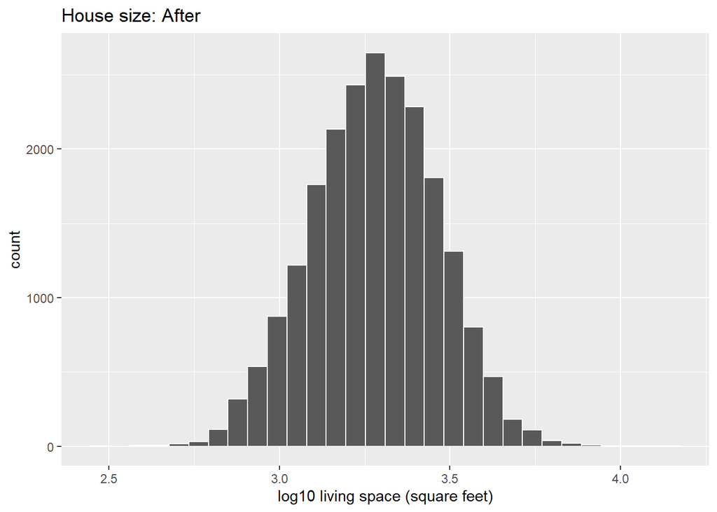

```r
# After:
ggplot(house_prices, aes(x = log10_size)) +
  geom_histogram(color = "white") +
  labs(x = "log10 living space (square feet)", title = "House size: After")
```

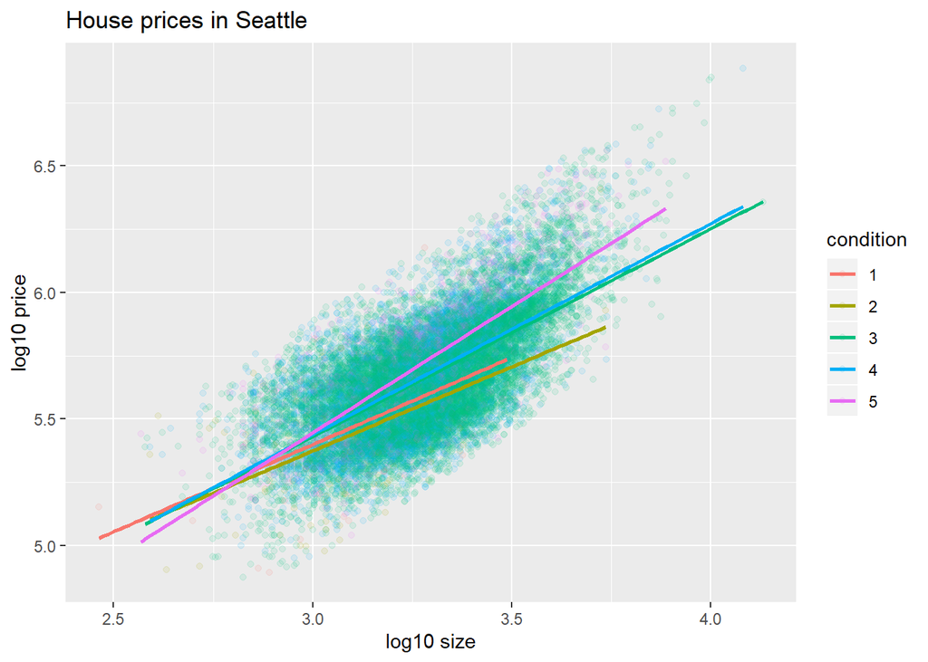

```r
ggplot(house_prices, aes(x = log10_size, y = log10_price, col = condition)) +
  geom_point(alpha = 0.1) +
  labs(y = "log10 price", x = "log10 size", title = "House prices in Seattle") +
  geom_smooth(method = "lm", se = FALSE)
```

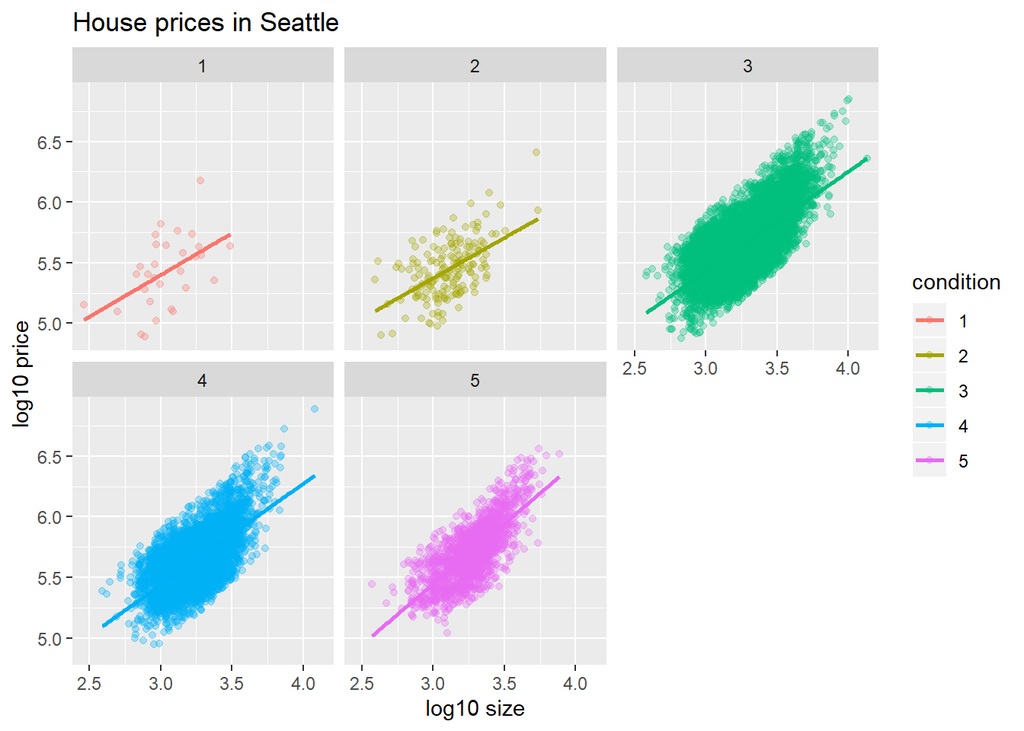

```r
ggplot(house_prices, aes(x = log10_size, y = log10_price, col = condition)) +
  geom_point(alpha = 0.3) +
  labs(y = "log10 price", x = "log10 size", title = "House prices in Seattle") +
  geom_smooth(method = "lm", se = FALSE) +
  facet_wrap(~condition)
```

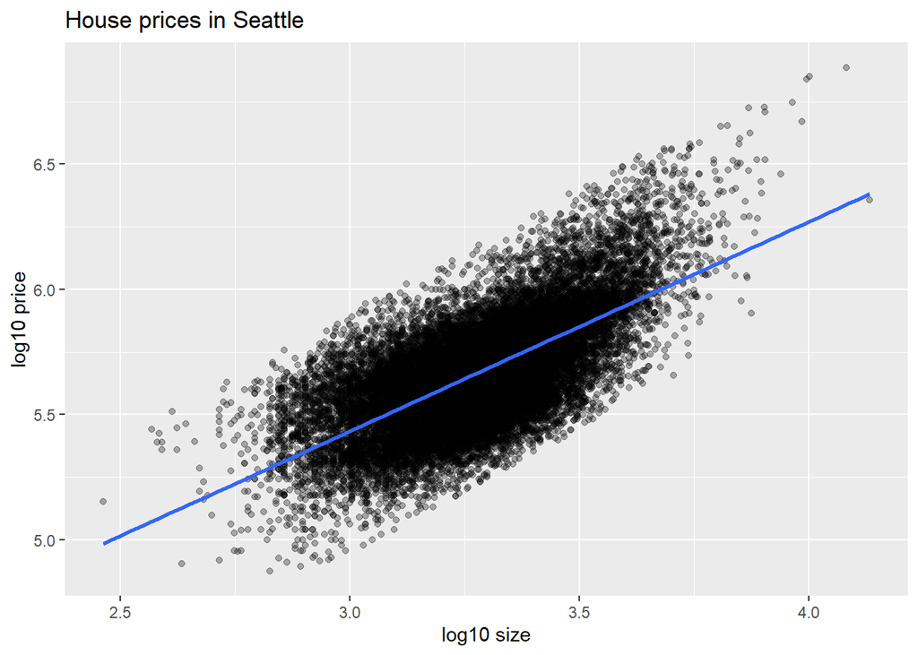

```r
ggplot(house_prices, aes(x = log10_size, y = log10_price)) +
  geom_point(alpha = 0.3) +
  labs(y = "log10 price", x = "log10 size", title = "House prices in Seattle") +
  geom_smooth(method = "lm", se = FALSE)
```

## Learning Check 12.1

Go ahead and run a regression that models the log10-transformed prices as the outcome variable and uses log10-transformed square footage as the explanatory variable. Note that this is a basic regression (and not a multiple regression).

```r
log_10_price_regression <- lm(log10_price ~ log10_size, data = house_prices)

get_regression_table(log_10_price_regression)
```

```
## # A tibble: 2 x 7
##   term       estimate std_error statistic p_value lower_ci upper_ci
##   <chr>         <dbl>     <dbl>     <dbl>   <dbl>    <dbl>    <dbl>
## 1 intercept     2.92      0.02       143.       0    2.88     2.96
## 2 log10_size    0.837     0.006      134.       0    0.825    0.849
```

## Learning Check 12.2

Use infer() to calculate a 95% confidence interval for the slope parameter in the previous regression.

```r
bootstrap_dist_slope <- house_prices %>%
  specify(formula = log10_price ~ log10_size) %>%
  generate(reps = 1000, type = "bootstrap") %>%
  calculate(stat = "slope")
bootstrap_dist_slope
```

```
## # A tibble: 1,000 x 2
##    replicate  stat
##        <int> <dbl>
##  1         1 0.828
##  2         2 0.831
##  3         3 0.827
##  4         4 0.842
##  5         5 0.830
##  6         6 0.837
##  7         7 0.834
##  8         8 0.833
##  9         9 0.834
## 10        10 0.838
## # ... with 990 more rows
```

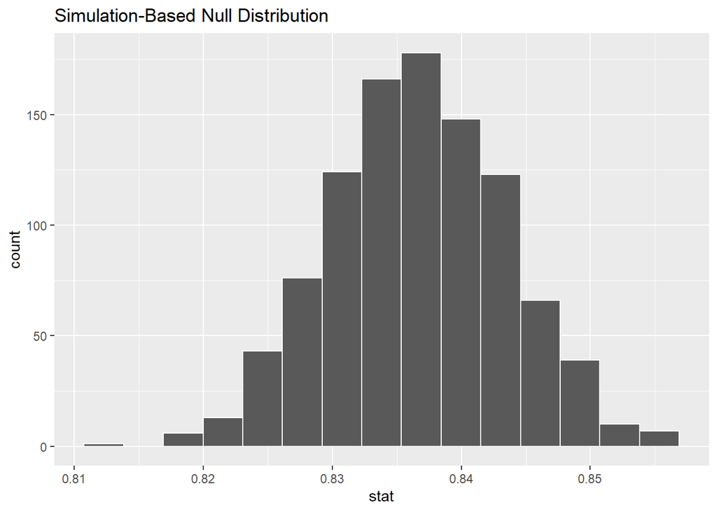

```r
visualize(bootstrap_dist_slope)
```

```r
percentile_confidence_interval_slope <- bootstrap_dist_slope %>%
  get_confidence_interval(type = "percentile", level = 0.95)
percentile_confidence_interval_slope
```

```
## # A tibble: 1 x 2
##   `2.5%` `97.5%`
##    <dbl>   <dbl>
## 1  0.824   0.850
```

## Learning Check 12.3

Hypothesis tests around the slope. Use infer() to generate a hypothesis around the relationship between log10_price and log10_size. Visualize the resulting distribution and shade the p value associated with your observed statistic. What is the value of p?

```r
null_distn_slope <- house_prices %>%
  specify(log10_price ~ log10_size) %>%
  hypothesize(null = "independence") %>%
  generate(reps = 1000, type = "permute") %>%
  calculate(stat = "slope")
null_distn_slope
```

```
## # A tibble: 1,000 x 2
##    replicate      stat
##        <int>     <dbl>
##  1         1  0.00336
##  2         2  0.00572
##  3         3  0.00675
##  4         4  0.00745
##  5         5 -0.000597
##  6         6 -0.0218
##  7         7 -0.00355
##  8         8 -0.00345
##  9         9  0.000271
## 10        10  0.00708
## # ... with 990 more rows
```

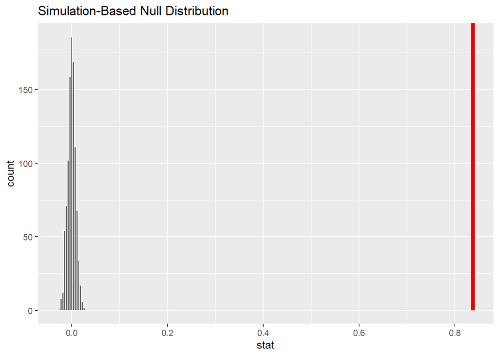

```r
visualize(null_distn_slope)+
  shade_p_value(obs_stat = get_regression_table(log_10_price_regression)$estimate[2], direction = "both")
```

```r
null_distn_slope %>%
  get_p_value(obs_stat = get_regression_table(log_10_price_regression)$estimate[2], direction = "both")
```

```
## # A tibble: 1 x 1
##   p_value
##     <dbl>
## 1       0
```

We have sufficient evidence to reject the null hypothesis that there is no relationship (thus a slope of zero) between the two variables because the p-value is 0, which is less than the 0.05 threshold set for the hypothesis test.

## Learning Check 12.4

Go ahead and run a regression that models the log10-transformed prices as the outcome variable and uses log10-transformed square footage and condition as the explanatory variables. Note that this is a multiple regression (and not a basic regression).

Is it possible to use infer() for multiple regression?

```r
multiple_regression_model <- lm(log10_price ~ log10_size*condition, data = house_prices)
get_regression_table(multiple_regression_model)
```

```
## # A tibble: 10 x 7
##    term              estimate std_error statistic p_value lower_ci upper_ci
##    <chr>                <dbl>     <dbl>     <dbl>   <dbl>    <dbl>    <dbl>
##  1 intercept            3.33      0.451     7.38    0        2.45     4.22
##  2 log10_size           0.69      0.148     4.65    0        0.399    0.98
##  3 condition2           0.047     0.498     0.094   0.925   -0.93     1.02
##  4 condition3          -0.367     0.452    -0.812   0.417   -1.25     0.519
##  5 condition4          -0.398     0.453    -0.879   0.38    -1.29     0.49
##  6 condition5          -0.883     0.457    -1.93    0.053   -1.78     0.013
##  7 log10_size:condi~   -0.024     0.163    -0.148   0.882   -0.344    0.295
##  8 log10_size:condi~    0.133     0.148     0.893   0.372   -0.158    0.424
##  9 log10_size:condi~    0.146     0.149     0.979   0.328   -0.146    0.437
## 10 log10_size:condi~    0.31      0.15      2.07    0.039    0.016    0.604
```

```r
reg_points <- get_regression_points(multiple_regression_model)
reg_points
```

```
## # A tibble: 21,613 x 6
##       ID log10_price log10_size condition log10_price_hat residual
##    <int>       <dbl>      <dbl> <fct>               <dbl>    <dbl>
##  1     1        5.35       3.07 3                    5.49   -0.143
##  2     2        5.73       3.41 3                    5.77   -0.036
##  3     3        5.26       2.89 3                    5.34   -0.081
##  4     4        5.78       3.29 5                    5.74    0.043
##  5     5        5.71       3.22 3                    5.62    0.093
##  6     6        6.09       3.73 3                    6.03    0.055
##  7     7        5.41       3.23 3                    5.62   -0.212
##  8     8        5.46       3.02 3                    5.45    0.015
##  9     9        5.36       3.25 3                    5.64   -0.275
## 10    10        5.51       3.28 3                    5.66   -0.148
## # ... with 21,603 more rows
```

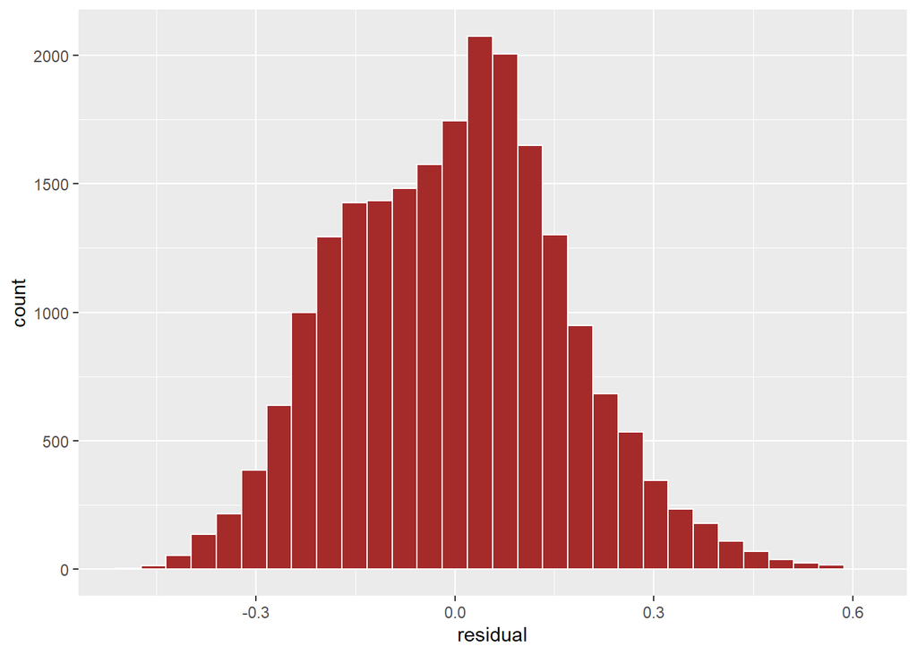

```r
ggplot(reg_points, aes(x = residual))+
  geom_histogram(color = 'white', fill = 'brown')
```

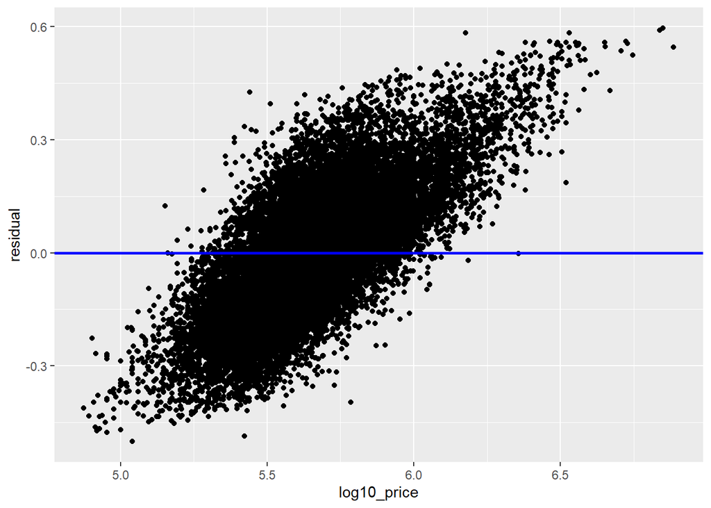

```r
ggplot(reg_points, aes(x = log10_price, y = residual))+
  geom_point()+
  geom_hline(yintercept = 0, col = "blue", size = 1)
```

It is possible to use infer for a multiple regression, so long as the multiple regression passes the LINE test. In this case, it is not possible because the multiple regression does not pass the E in the line test. The variance has a clear pattern trending upward from 5 - 6.5 and thus the infer package should not be used in this case.